# PS2

Becky Lau

October 18, 2019

## **Computation Part 1**

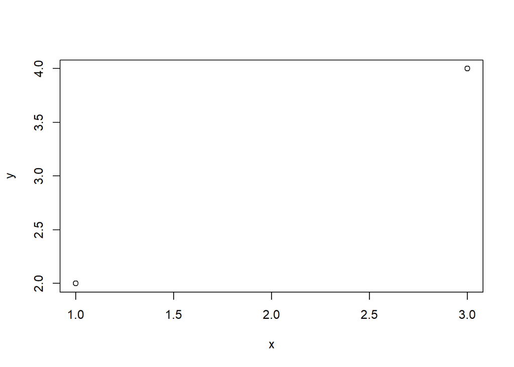

```r
# create dataframe from vectors

raw <- as.data.frame(cbind(c(1,3),c(2,4)))%>%
  rename(x = V1, y = V2)

rownames(raw) <- c("p","q")

plot(raw)
```

## Scale and view

```r
df <- raw %>% scale()
df <- as.data.frame(df)
glimpse(df)
```

```
## Observations: 2
## Variables: 2
## $ x <dbl> -0.7071068, 0.7071068
## $ y <dbl> -0.7071068, 0.7071068
```

## Euclidean (by hand)

```r
# values from scaled vectors
x1 = -0.7071068
x2 = 0.7071068
y1 = -0.7071068
y2 = 0.7071068

euclidean_sum <- (x1-x2)^2+ (y1-y2)^2
euclidean_hand <- sqrt(euclidean_sum)

euclidean_hand
```

```
## [1] 2
```

## Manhattan (by hand)

```r
manhattan_hand <- abs(x1-x2)+ abs(y1-y2)

manhattan_hand
```

```
## [1] 2.828427
```

## Canberra (by hand)

```r
canberra_1 <- abs(x1-x2)/(abs(x1)+abs(x2))
canberra_2 <- abs(y1-y2)/(abs(y1)+abs(y2))
canberra_hand <- canberra_1 + canberra_2
canberra_hand
```

```
## [1] 2
```

## Euclidean (using dist fn)

```r
euclidean <-
  df%>%
  dist(method = "euclidean")

euclidean
```

```
##   p
## q 2
```

## Manhattan (using dist fn)

```r
manhattan <-
  df%>%
  dist(method = "manhattan")

manhattan
```

```
##          p
## q 2.828427
```

## Canberra (using dist fn)

```r
canberra <-
  df%>%
  dist(method = "canberra")

canberra
```

```
##   p
## q 2
```

Originally my hand calculations did not match those generated with the dist function because I forgot to use scaled values in my hand calculations.

There are many key differences between these measures. Euclidean distance is the most intuitive way of representing distance, as defined by the pythagorean thereom. Manhattan distance is also known as “city block” distance. Canberra is a weighted version of Manhattan distance that is often used for data scattered around an origin. These differences are important because different measures of similarity may be more appropriate for specific kinds of data (e.g. norms in the field of study, how the data is clustered/structured, mixed data vs. continuous data).

I notice that in the fictitious data, Manhattan distance seems to generate a higher value than Euclidean, probably because Euclidean distance is the shortest distance possible between two points. The Canverra distance gives the same value as Euclidean in the dataset.

## **Computation Part 2**

```r
faith <- as.data.frame(faithful)
```

## Scatterplot

The scatterplot shows that there are two clusters of data (defined by density) when plotting eruptions against waiting time.

There is generally a positive relationship between waiting time and eruptions, although the relationship may deviate from a linear relationship.

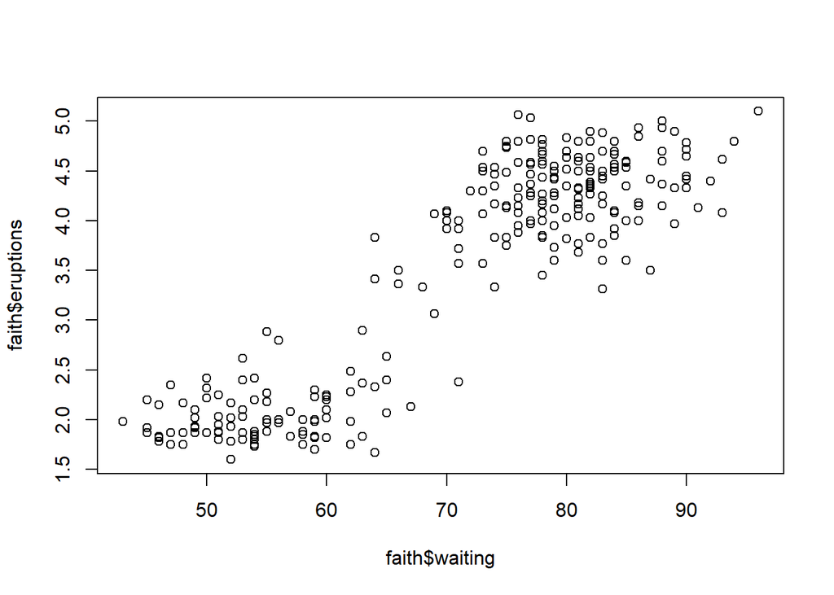

```r
plot(faith$waiting, faith$eruptions)
```

## centrality measures

The means of eruptions and waiting time data are about 3.5 and 70.9 respectively. The standard deviation of wait time is larger than that of eruptions.

```r
mean(faith$eruptions)
```

```
## [1] 3.487783
```

```r
sd(faith$eruptions)
```

```
## [1] 1.141371
```

```r
mean(faith$waiting)
```

```
## [1] 70.89706
```

```r
sd(faith$waiting)
```

```
## [1] 13.59497
```

## boxplot of eruptions

There doesn’t seem to be outliers in the data. The data seems slightly skewed.

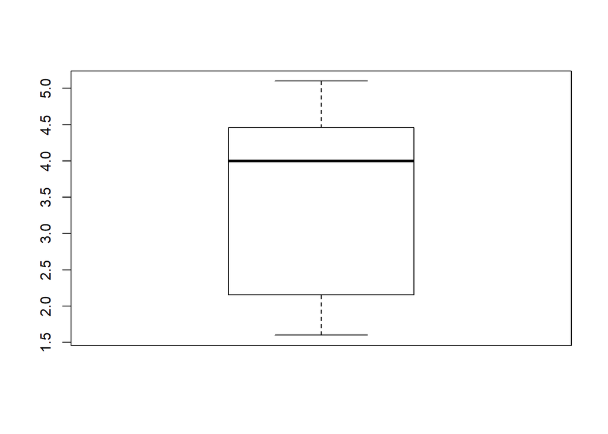

```r
boxplot(faith$eruptions)
```

## boxplot of waiting

There doesn’t seem to be outliers in the data. The data seems slightly skewed.

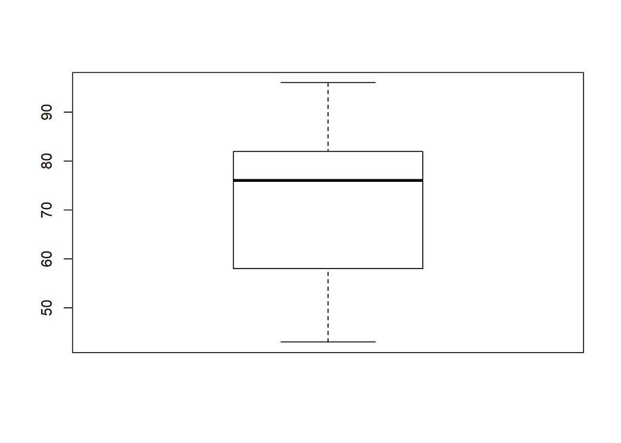

```r
boxplot(faith$waiting)
```

## scale and calculate dissilmilarity matrix

```r
x_scaled <- scale(faith)
x_dist <- dist(x_scaled, method = "euclidean")
x_dist
```

[output not shown]

[output cut: 14905 more lines]

[output not shown]

## odi

The ODI shows that there are two main clusters in the data. One cluster has a larger number of datapoints than the other.

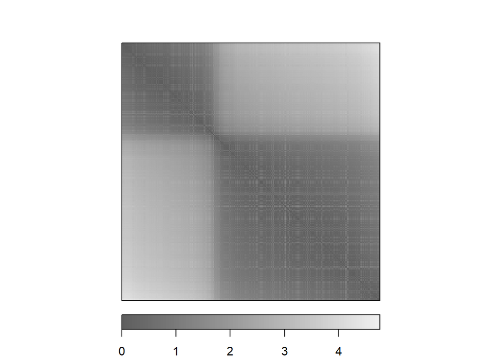

```r
seriation::dissplot(x_dist)
```

## **Computation part 3**

## Iris data dissimilarity matrix

```r
iris <- as.data.frame(iris)%>%
  select(Sepal.Length, Petal.Width)

x_scaled <- scale(iris)
x_dist <- dist(x_scaled, method = "euclidean")
x_dist
```

[output not shown]

[output cut: 3245 more lines]

[output not shown]

## Iris dendrogram

There are broadly 4 large clusters. The clusters are relatively balanced.

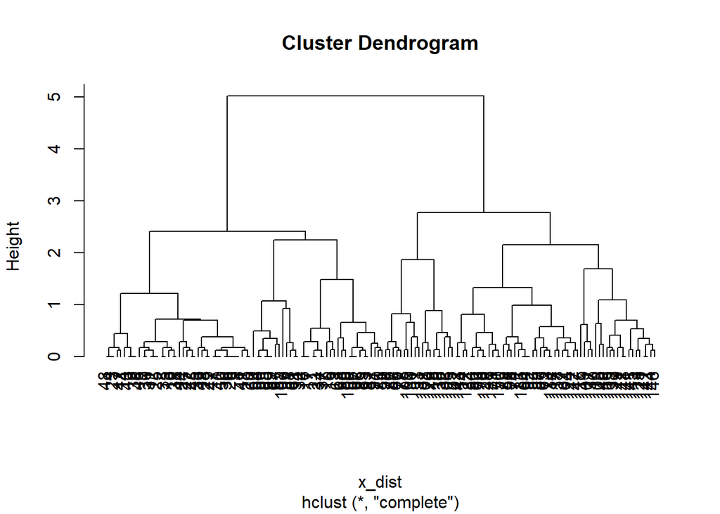

```r
hc_complete <- hclust(x_dist,
                      method = "complete"); plot(hc_complete, hang = -1)
```

## Iris cuts

When cutting at 2nd and 3rd branches, there are 76 datapoints in the first cluster. When cutting at the 2nd branch, there are 74 datapoints in the second cluster. When cutting at the 3rd branch, there are 19 datapoints in the second cluster and 55 datapoints in the third cluster.

```r
cuts <- cutree(hc_complete,
            k = c(2,3))

table(`2 Clusters` = cuts[,1],
      `3 Clusters` = cuts[,2])
```

```
##           3 Clusters
## 2 Clusters  1  2  3
##          1 76  0  0
##          2  0 19 55
```

## Iris single vs complete linkage

Complete linkage creates a more balanced dendrogram than single linkage.

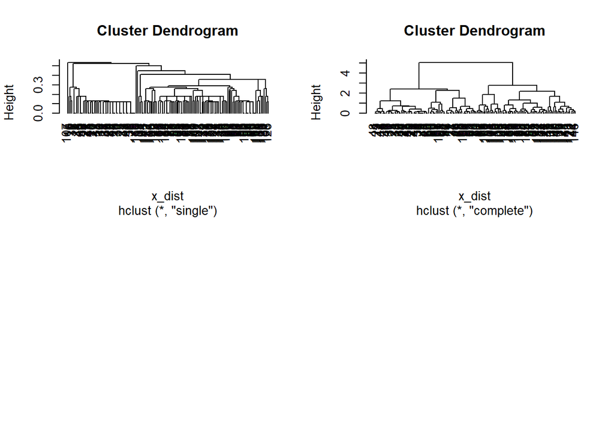

```r
par(mfrow = c(2,2))

hc_single <- hclust(x_dist,
                 method = "single"); plot(hc_single, hang = -1)

hc_complete <- hclust(x_dist,
                      method = "complete"); plot(hc_complete, hang = -1)

par(mfrow = c(1,1))
```

## Critical thinking

1. Assessing clusterability

Clusterability may be diagnosesd informally through simple distribution plots, visually through VAT or ODI plots, and mathemtaically through sparse sampling (e.g. Hopkins). For more informal and visual techniques, we are generally looking to see if there are groups/clusters that emerge, either in terms of location, shape or density. For mathematical approaches, we compare our actual data with a simulated uniform distribution (random noise, no clusters) to see if clustering is likely.

I would not proceed if the data doesn’t look clusterable, because the data would not be meaningful. Other analyses might make more sense.I might also see if the data can be clustered through other features.

2. Locate a paper

Citation: Mi, Q., Keung, J., & Yu, Y. (2016, September). Measuring the stylistic inconsistency in software projects using hierarchical agglomerative clustering. In Proceedings of the The 12th International Conference on Predictive Models and Data Analytics in Software Engineering (p. 5). ACM.

This paper attempts to measure the degree of inconsistency in programming style within a software project team using HAC. The authors propose a stylitic fingerprint technique to characterize these styles.

The authors go through similar steps that we covered this week. To set the stage for clustering, all variables were scaled so that they were comparable and contribute equally. Distance was defined as Euclidean distances. Clusterability was assessed by using the Hopkins statistic, to compare actual data with simulated randomness. The paper discusses the type of linkage method that they choose (Ward’s method), which is one of the most popular methods for text-mining. Finally dendrograms are also used to visualize the results.

One extension of these findings could be to see if human judges would agree with how inconsistencies in style are categorized and picked up by the bottom-up clustering approach (pairing supervised with unsupervised approaches). Another limitation pointed out by the authors is that the metric is not very fine-grained. The inconsistency is defined at a source file level, which means anomalies in a smaller code block may not be picked up by the HAC analysis reported here